# FIGI PhysAct Requests Feb 8th 2022

AK

2022-02-09

### 1. Total sample size for active_met_875

> In table 1 by outcome (active_met_875_main_effects) there is specified a total of 39992 observations (23609 controls and 16383 cases). For the continuous and quartile variable we have a total of 42602 observations (25309 controls and 17293 cases).  
> Just to double check, the active_met_875 do not include those studies that have only 1 category isn’t it? In other words, we have excluded a total of 2610 observations, right?

yes that is correct

### 2. Suggestive_gxe_info Drive folder

> Is this folder updated with the latest changes?

yes I updated the results tables + regional plots. to be sure, it should be folder under `Gene-Environment Interaction/Analysis Plans/Physical Activity/results_20220128`

### 3. energytot_imp (when applicable)

> In all “xxx_gwis.html” files there is a summary of methods/plots section -very helpful, by the way ;) -. Regarding the energy variable. If I have understood this correctly, all models were adjusted by age, sex, study and the 3 PCs. For those studies that energy is available, energy intake was also included as a covariate, isn’t it?

That is correct. If the study doesn’t have energytot_imp available, all individuals have value = 0. Models are meant to include ‘energytot.missing’ to account for this, but since scans already adjust for study_gxe, we decided only to include energytot_imp.

```r
# input variables
exposure = 'methrswklns'
hrc_version = 'v3.1'
path = glue("/media/work/gwis_test/{exposure}/")

# input data
esubset <- readRDS(glue("/media/work/gwis_test/{exposure}/data/FIGI_{hrc_version}_gxeset_{exposure}_basic_covars_glm.rds")) %>%
  pull(vcfid)

input_data <- readRDS(glue("/media/work/gwis_test/data/FIGI_{hrc_version}_gxeset_analysis_data_glm.rds")) %>%
  filter(vcfid %in% esubset)

kable(input_data %>%
  group_by(study_gxe) %>%
  summarise(mean = mean(energytot_imp), n = n()))
```

| study_gxe | mean | n |
| --- | --- | --- |
| Colo23 | 2115.347 | 208 |
| CPSII_1 | 1724.510 | 1027 |
| CPSII_2 | 1685.612 | 645 |
| DACHS_1 | 0.000 | 3313 |
| DACHS_2 | 0.000 | 1141 |
| DACHS_3 | 0.000 | 1831 |
| DALS_1 | 2336.523 | 1400 |
| DALS_2 | 2305.105 | 859 |
| EPIC | 2105.888 | 3488 |
| HPFS_1 | 2021.316 | 449 |
| HPFS_2 | 1959.021 | 343 |
| HPFS_3_AD | 2012.065 | 597 |
| HPFS_4 | 2007.120 | 380 |
| HPFS_5_AD | 1979.153 | 260 |
| LCCS | 2303.303 | 2079 |
| MEC_1 | 2001.818 | 661 |
| MEC_2 | 2071.971 | 145 |
| NCCCSI | 1868.809 | 697 |
| NFCCR_2 | 2357.697 | 650 |
| NHS_1 | 1715.679 | 973 |
| NHS_2 | 1714.639 | 286 |
| NHS_3_AD | 1748.648 | 896 |
| NHS_4 | 1674.738 | 531 |
| NHS_5_AD | 1715.564 | 457 |
| NHSII | 1815.242 | 197 |
| SMC_COSM | 2240.465 | 1118 |
| UKB_1 | 0.000 | 13555 |
| VITAL | 1827.561 | 543 |
| WHI_1_Rematch | 1487.973 | 960 |
| WHI_2 | 1668.059 | 1851 |
| WHI_3 | 1645.839 | 1062 |

```r
table(input_data$study_gxe, input_data$energytot.missing)
```

```
##
##                     0     1
##   Colo23          208     0
##   CPSII_1        1027     0
##   CPSII_2         645     0
##   DACHS_1           0  3313
##   DACHS_2           0  1141
##   DACHS_3           0  1831
##   DALS_1         1400     0
##   DALS_2          859     0
##   EPIC           3488     0
##   HPFS_1          449     0
##   HPFS_2          343     0
##   HPFS_3_AD       597     0
##   HPFS_4          380     0
##   HPFS_5_AD       260     0
##   LCCS           2079     0
##   MEC_1           661     0
##   MEC_2           145     0
##   NCCCSI          697     0
##   NFCCR_2         650     0
##   NHS_1           973     0
##   NHS_2           286     0
##   NHS_3_AD        896     0
##   NHS_4           531     0
##   NHS_5_AD        457     0
##   NHSII           197     0
##   SMC_COSM       1118     0
##   UKB_1             0 13555
##   VITAL           543     0
##   WHI_1_Rematch   960     0
##   WHI_2          1851     0
##   WHI_3          1062     0
```

### 4. posthoc analysis files

> In all posthoc analysis files there is mentioned “Plots of model predicted outcome by 1 unit increase of exposure/allelic dosage”. We cannot see this part. Are these plots planned for future steps?

They look like the plot below. I found that it causes more confusion than not when presenting this to the group. I think including odds ratios forest plots stratified by genotypes is more useful (although I haven’t generated those normally)

let me know if you want me to create these plots

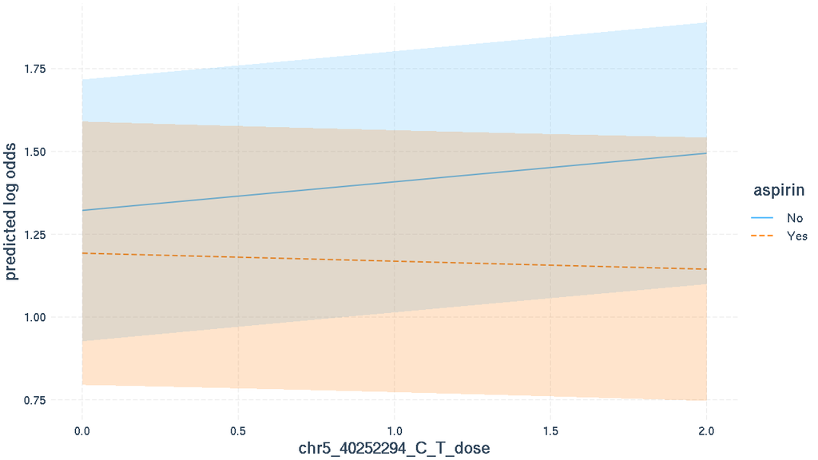

```r
knitr::include_graphics("/media/work/gwis_test/aspirin/output/posthoc/interaction_plot_aspirin_v2.4_chr5_40252294_C_T_dose_age_ref_imp_pc1_pc2_pc3_sex_study_gxe.png")
```

### 5. active_met_875 posthoc analysis file

> For “chr13_61572969_G_A” there is no “stratified OR” window. Is there any reason for that?

I originally excluded because this finding is showing E|G association rather than an interaction. However, I agree it should be included — I uploaded a new version of the posthoc result file for active_met_875

### 6. methrswklnsqc2 posthoc analysis file.

> The Stratified OR table for “chr20_49693755_T_C” has two rows: “methrswklnsqc2=0” and “methrswklnsqc2=1”. This variable is a study specific quartile-based variable. Can you explain what zero and 1 means?

For methrswklnsqc2, quartiles are modelled as continuous variables. A unit increase is an increase in quartile value, and the reference group is the lowest quartile.